# Artigo Bayesiana - Sem volatilidade estocástica

Aishameriane Schmidt

16 de junho de 2017

# Data

## Description

The series that are going to be used in the VAR model are:

- IPCA index, for inflation (% monthly);
- SELIC tax, for interest rate (% monthly);
- Exchange rate, R$/US$, (comercial, compra, média do período). Obs: inflação já descontada, a taxa está em termos reais.
- IBC-Br index (economic activity index, calculated by the Central Bank)

More about the data can be found [here](https://htmlpreview.github.io/?https://github.com/aishameriane/msc-economics/blob/master/Bayesian-macro/article/self-study/Artigo_Aisha_descritivo.html)

```r
library(tseries)
dados <- read.csv("C:\\Users\\Aishameriane\\OneDrive\\Documentos\\Mestrado Economia\\Bayesiana - 2017-01\\Materiais artigo\\Dados\\dados_final.csv", sep = ",", header = TRUE, dec = ".")

for (i in 2:ncol(dados)) {
  dados[,i]<-ts(dados[,i], start = c(2004,1), frequency = 12)
}

head(dados)
```

```
##         Data   IBCraw    IBCvar  IPCAraw  IPCAvar SELICraw  SELICvar
## 1 2004-01-01 102.5377 2.5377015 107.7073 7.707318 64.30137 -35.69863
## 2 2004-02-01 103.4321 0.7905138 108.3642 6.688916 55.01003 -40.75580
## 3 2004-03-01 116.4639 8.2873997 108.8734 5.887647 69.96128 -22.39121
## 4 2004-04-01 111.6589 5.0592034 109.2761 5.258418 59.95386 -36.85333
## 5 2004-05-01 110.2756 5.7128614 109.8332 5.153546 62.28510 -37.52748
## 6 2004-06-01 111.2845 8.5412863 110.6128 6.059129 62.39082 -33.75866
##    EXRTraw    EXRTvar
## 1 82.93577 -17.064231
## 2 85.21934 -18.398329
## 3 84.49791 -15.710513
## 4 84.51245  -6.821899
## 5 90.16756   4.896951
## 6 91.00244   8.531085
```

```r
columns<-c(3,5,7,9)
Yraw <- dados[,columns]
head(Yraw)
```

```
##      IBCvar  IPCAvar  SELICvar    EXRTvar
## 1 2.5377015 7.707318 -35.69863 -17.064231
## 2 0.7905138 6.688916 -40.75580 -18.398329
## 3 8.2873997 5.887647 -22.39121 -15.710513
## 4 5.0592034 5.258418 -36.85333  -6.821899
## 5 5.7128614 5.153546 -37.52748   4.896951
## 6 8.5412863 6.059129 -33.75866   8.531085
```

# Koops Code for regular VAR

Intro: Bayesian estimation, prediction and impulse response analysis in VAR models. Dependent on your choice of forecasting, the VAR model is:

- Iterated forecasts:

$$\begin{equation}
Y_t = A_0 + Y_{t-1} \times A_1 + ... + Y_{t-p} \times A_p + \varepsilon_t
\end{equation}$$

so that in this case there are $p$ lags of $Y$ (from $1$ to $p$).

- Direct h-step ahead foreacsts:

$$\begin{equation}
Y_{t+h} = A_0 + Y_t \times A_1 + ... + Y_{t-p+1} \times A_p + \varepsilon_{t+h}
\end{equation}$$

so that in this case there are also $p$ lags of $Y$ (from $0$ to $p-1$).

In any of the two cases, the model is written as:

$$\begin{equation}
Y(t) = X_(t) \times A + \varepsilon(t)
\end{equation}$$

where $\varepsilon_t \sim \mathcal{N}(0,\sigma)$, and $A$ summarizes all parameters. Note that we also use the vector $a$ which is defined as $a=vec(A)$.

## Load data

Koop’s says to name the data `Yraw`, to avoid changing the code. He also points out that `Yraw`is a matrix with $T$ rows ($T$ is the number os time series observarions, usually months or quarters) and $M$ columns, with the macro data for each VAR component. Since my data is not structured like this - I gonna need get rid of the extra data.

```r
readLines("C:\\Users\\Aishameriane\\OneDrive\\Documentos\\Mestrado Economia\\Bayesiana - 2017-01\\Materiais artigo\\Dados\\Códigos Koop\\BVAR_Analytical\\Yraw.dat", n=10)

Yraw <- read.table("C:\\Users\\Aishameriane\\OneDrive\\Documentos\\Mestrado Economia\\Bayesiana - 2017-01\\Materiais artigo\\Dados\\Códigos Koop\\BVAR_Analytical\\Yraw.dat", header=FALSE, sep="\t")
```

[output not shown]

## Preliminaries

Definying the specification of the VAR model.

```r
# Constant =1 for intercept and =0 for regression starting on origin
constant = 1

# Number of lags on dependent variables
p = 1

# Compute h-step ahead predictions; 0 for no prediction
forecasting = 1

# Forecast method: 0 - direct; 1 - iterated
forecast_method = 0

# Number of forecast periods
h = 3

# Prior setup: 1- non informative; 2 - minnesota; 3 - natural conjugate
prior = 2
```

## Data handling

```r
# Get initial dimensions of the dependent variable
# The function size() in matlab returns a vector with the number of rows and the number of columns of an object. Its correspondence is dim() in R
# [Traw M] = size(Yraw) associate with Traw the number of lines in Yraw and associates M the number of columns in Yraw

Traw <- nrow(Yraw)
M <- ncol(Yraw)

if (forecasting == 1) {
  if (h <= 0) {
    print("You cannot have less periods than 1 for forecasting, please change your h.")
  } else if (forecast_method == 0) { # Direct forecasts
       Y1 = Yraw[(h+1):Traw,]
       Y2 = Yraw[2:(Traw-h),]
       Traw = Traw - h - 1
  } else if (forecast_method == 1) { # Iterated forecasts
      Y1 = Yraw
      Y2 = Yraw
  } else
      print("Wrong choice of forecast_method.")
} else {
      Y1 = Yraw
      Y2 = Yraw
}

# Creates the analogous to mlag2 function

mlag2 <- function(B,p){
  N <- ncol(B)
  l <- embed(as.matrix(B),p)
  zeros <- matrix(rep(0, p^2*N) , nrow=p, ncol = N*p)
  data.frame(rbind(zeros,l)[1:nrow(B),])
}

# Generate lagged Y matrix. This will be part of the X matrix.
## Y is [T x M]. Ylag is [T x (Mp)]
Ylag <- mlag2(Y2, p)

# Now define X matrix: it has all the variables: constant, lags of the dependent variable
## exogenous regressors/dummies

if (constant == 1) {
  X1 <- cbind(as.matrix(rep(1, Traw-p), ncol=1), Ylag[(p+1):Traw,])
} else {
  X1 <- Ylag[(p+1):Traw,]
}

# Get the dimensions of X matrix

Traw3 <- nrow(X1)
K <- ncol(X1)

# Creates the block diagonal matrix Z
## eye(M) in Matlab returns the identity matrix with the size MxM - the equivalent in R is diag(M)
###remember that M is the number of columns in the original data Yraw
## kron(M,X1) in matlab gives the kroenecker tensor product between two matrices
Z1 <- kronecker(diag(M),as.matrix(X1))

# Form Y matrix accordingly
# Delete first "lags" rows to match the dimensions of X matrix
## This is the final Y matrix used for the VAR

Y1 <- Y1[(p+1):Traw,]

# Traw was the number of time observations (lines) in Yraw (original data)
# Tesao (cannot use T because is a function in R) is the number of actual time series observations of Y and X (we discount the p lags from Traw)

Tesao <- Traw - p
```

## Forecasting set-up

```r
# Keeping the last "h" (or 1) observarions to evaluate (pseudo) forecasting (to evaluate quality)

if (forecasting == 1) {
  if (forecast_method == 0) { # Direct forecasts, only use the last observation
    Y <- Y1[1:(nrow(Y1)-1),]
    X <- X1[1:(nrow(X1)-1),]
    Z <- kronecker(diag(M),as.matrix(X))
    Tesao <- Tesao - 1
  } else { # indirect forecasts
      Y <- Y1[1:(nrow(Y1)-h),]
      X <- X1[1:(nrow(X1)-h),]
      Z <- kronecker(diag(M),as.matrix(X))
      Tesao <- Tesao - h
  }
} else {
    Y <- Y1
    X <- X1
    Z <- Z1
}
```

## Priors

```r
# First step is to get the OLS estimators
## inv() in matlab is the inverse matrix and * is the matricial product. In R the function to invert a square matrix is
## solve() and the matrix product is given by %*%. The transpose in Matlab is A' and in R is t(A)

A_OLS <- solve(t(as.matrix(X)) %*% as.matrix(X)) %*% (t(as.matrix(X)) %*% as.matrix(Y)) # This is the matrix of regression coefficients
a_OLS <- as.vector(A_OLS) # Transform into a single vector, piling up the coefficients from A_OLS. So a_OLS = vec(A_OLS)

SSE <- t((as.matrix(Y)-as.matrix(X) %*% as.matrix(A_OLS))) %*% (as.matrix(Y)-as.matrix(X) %*% as.matrix(A_OLS))
SIGMA_OLS = SSE/(Tesao-K)

# Getting the hyperparameters for bvar model

## Define hyperparameters

if (prior == 1) { # noninformative prior
 # Nothing happens, the posterior will depend on OLS quantities
} else if (prior ==2 ) { # the Minnesota prior
  A_prior <- 0*matrix(rep(1, K*M), ncol = M)
  a_prior <- as.vector(A_prior)

  # Hyperparameters on the Minnesota variance of alpha --- check this later with Guilherme
  a_bar_1 <- 0.5
  a_bar_2 <- 0.5
  a_bar_3 <- 10^2

  # Now we get the residual variances of univariate p-lag autoregressions
  ## (i.e., we are going to estimate M AR(p) models, one for each column of Yraw).
  ## Here we just run the AR(p) model on each equation, ignoring the constant and exogenous variables
  ## (if they have beeen specificed for the original var model)
  ## I have no idea why Koop didn't use something like autoarima() and instead went through all the trouble doing the estimates by hand

  sigma_sq <- matrix(rep(0, M), ncol=1)

  for (i in 1:M){
    # Create lags of dependent variable in i-th equation
    Ylag_i <- mlag2(as.matrix(Yraw[,i]),p)
    Ylag_i <- Ylag_i[(p+1):Traw,]
    # Dependent variable in i-th equation
    Y_i = Yraw[(p+1):Traw,i]

    # OLS estimates of i-th equation

    alpha_i <- solve(t(as.matrix(Ylag_i)) %*% as.matrix(Ylag_i)) %*% (t(as.matrix(Ylag_i)) %*% as.matrix(Y_i))
    sigma_sq[i,1] <- (1/(Tesao-p+1)) * t(as.matrix(Y_i)-as.matrix(Ylag_i) %*% alpha_i) %*% (as.matrix(Y_i)-as.matrix(Ylag_i) %*% alpha_i)
  }

  # Now we define the prior hyperparameters
  ## First, create an array of dimensions K x M, which will contain the K diagonal elements of the covariance matrix
  ## in each of the M equations

  V_i <- matrix(rep(0, K*M), ncol = M)

  # index in each equation which are the own lags

  ind <- matrix(rep(0, p*M), ncol = p)

  for (i in 1:M){
    ind[i,] <- seq(from = constant+i, to = K, by = M)
  }

  for (i in 1:M) { # for each i-th equation
    for (j in 1:K) { # for each j-th RHS variable (wtf the fuck is RHS?) - the code below is the function by parts from the class
      if (constant == 1) {
        if (j == 1) {
          V_i[j,i] = a_bar_3 * sigma_sq[i,1] # Variance on constant
        } else if ((j %in% ind[i,])>0) {
            V_i[j,i] <- a_bar_1/(ceiling((j-1)/M)^2) # Variance of own lags
         } else {
            for (k_j in 1:M) {
              if ((j %in% ind[k_j,])>0) {
                l_l <- k_j
              }
            }
             V_i[j,i] <- (a_bar_2 * sigma_sq[i,1])/((ceiling((j-1)/M)^2)*sigma_sq[l_l,1])
          }
      } else {
          if ((j %in% ind[i,])>0) {
            V_i[j,i] <- a_bar_1/(ceiling((j-1)/M)^2) # Variance of own lags
          } else {
            for (k_j in 1:M) {
              if ((j %in% ind[k_j,])>0) {
                l_l <- k_j
              }
            }
            V_i[j,i] <- (a_bar_2 * sigma_sq[i,1])/((ceiling((j-1)/M)^2)*sigma_sq[l_l,1])
          }
        }
      }
  }
  # Now V is a diagonal matrix with diagonal elements the V_i
  ## <So proud I could figure it out after some time thinking, some pizza, screams and frustration>
  V_prior <- diag(as.vector(V_i))

  # SIGMA is equal to the OLS quantity
  SIGMA <- SIGMA_OLS
} else if (prior == 3) { # The Normal-Wishart prior (conjugate natural)
    # Hyperparameters on a ~ N(a_prior, SIGMA x V_prior)
    A_prior <- 0*matrix(rep(1, K*M), ncol = M)
    a_prior <- as.vector(A_prior)
    V_prior <- 10*diag(K)
    # Hyperparameters in inv(SIGMA) ~ W(nu_prior, inv(S_prior))
    # I changed from v (lower) to nu because it is very confusing to use V and v for V_prior and v_prior,
    ## (for god sake, life is already messy without this additional complication)
    nu_prior <- M
    S_prior <- diag(M)
    inv_S_prior <- solve(S_prior)
}

# A little dramatic pause for appreciation, this was hard.
```

# Posterior

```r
# Posterior hyperparameters of ALPHA and SIGMA with noninformative (diffuse) prior
  if (prior == 1) {
    # Posterior of alpha|Data ~ Multivariate-T(kron(SSE, inv(X'X)), alpha_OLS, T-K)
    V_post <- solve(t(as.matrix(X)) %*% as.matrix(X))
    a_post <- a_OLS
    A_post <- matrix(a_post, ncol=M, byrow=FALSE)

    # Posterior of SIGMA|Data ~ inv~Wishart(SSE, T-K)
    S_post <- SSE
    nu_post <- Tesao-K

    # Now get the mean and variance of the Multi-t marginal posterior of alpha
    alpha_mean <- a_post
    alpha_var <- (1/(nu_post-M-1))*kronecker(as.matrix(S_post), as.matrix(V_post))
  } else if (prior == 2) { # Posterior hyperparameters of Alpha and Sigma with Minnesota Prior
    # Get all the required quantities for the posteriors
    V_post <- solve(solve(as.matrix(V_prior)) + kronecker(solve(as.matrix(SIGMA)),t(as.matrix(X)) %*% as.matrix(X)))
    a_post <- as.matrix(V_post) %*% (solve(as.matrix(V_prior)) %*% as.matrix(a_prior) + kronecker(solve(as.matrix(SIGMA)), t(as.matrix(X)) %*% as.matrix(X)) %*% as.matrix(a_OLS))
    A_post <- matrix(a_post, ncol=M, byrow=FALSE)

    # In this case, the mean is a_post and the variance is V_post -- CHECK WHY
    alpha_mean <- a_post
    alpha_var <- V_post # In koop's code this one is missing
  } else if (prior == 3) { # Posterior hyperparameters of alpha and SIGMA with Normal-Wishart prior
    # Get all the required quantities for the posteriors
    ## For alpha
    V_post <- solve(solve(as.matrix(V_prior))+ t(as.matrix(X) %*% as.matrix(X)))
    A_post <- V_post %*% (solve(as.matrix(V_prior)) %*% as.matrix(A_prior) + t(as.matrix(X) %*% as.matrix(X) %*% A_OLS))
    a_post <- as.vector(A_post)

    # For sigma
    S_post <- SSE + S_prior +
      t(as.matrix(A_OLS)) %*% t(as.matrix(X)) %*% as.matrix(X) %*% A_OLS +
      t(as.matrix(A_prior)) %*% solve(as.matrix(V_prior)) %*% as.matrix(A_prior) -
      t(as.matrix(A_post)) %*% (solve(as.matrix(V_prior))+ t(as.matrix(X)) %*% as.matrix(X)) %*% as.matrix(A_post)
    nu_post <- Tesao + nu_prior

    # Now get the mean and variance of the Multi-t marginal posterior of alpha
    alpha_mean <- a_post
    alpha_var <- (1/(nu_post - M - 1)) %*% kronecker(S_post, V_post) # changed from v to nu here as well
  }
```

## Predictive Inference

```r
  if (forecasting == 1) {
    if (2 > (M*(p-1)+1)) { # This if is because R can invert vectors if the first entrance is bigger than the second, while matlab doesn't
  X_tplus1 <- as.numeric(paste(c(1, Y[Tesao,])))
  Pred_mean <- matrix(X_tplus1, nrow=1) %*% as.matrix(A_post)
    } else {
  X_tplus1 <- as.numeric(paste(c(1, Y[Tesao, ], X[Tesao, 2:(M*(p-1)+1)])))
  Pred_mean <- matrix(X_tplus1, nrow=1) %*% as.matrix(A_post)
    }
  }
```

## Printing results (yay)

I gonna need to work out a way to exibit the results without getting too messy.

```r
# Mean of alpha
round(alpha_mean,2)
```

```
##         [,1]
##  [1,]   3.61
##  [2,]   0.47
##  [3,]  -0.39
##  [4,]  -0.05
##  [5,]  -0.06
##  [6,]   0.50
##  [7,]   0.08
##  [8,]   0.88
##  [9,]   0.00
## [10,]   0.02
## [11,] -26.98
## [12,]   1.91
## [13,]   3.77
## [14,]   0.76
## [15,]   0.04
## [16,]  -2.48
## [17,]   0.50
## [18,]   0.30
## [19,]   0.10
## [20,]   0.81
```

```r
# Var of alpha
round(alpha_var, 2)
```

```
##        [,1]  [,2]  [,3] [,4] [,5]  [,6]  [,7]  [,8] [,9] [,10] [,11] [,12]
##  [1,]  0.78 -0.02 -0.11 0.00    0  0.05  0.00 -0.01    0     0  1.63 -0.05
##  [2,] -0.02  0.00  0.00 0.00    0  0.00  0.00  0.00    0     0 -0.05  0.01
##  [3,] -0.11  0.00  0.02 0.00    0 -0.01  0.00  0.00    0     0 -0.24  0.01
##  [4,]  0.00  0.00  0.00 0.00    0  0.00  0.00  0.00    0     0  0.01  0.00
##  [5,]  0.00  0.00  0.00 0.00    0  0.00  0.00  0.00    0     0  0.00  0.00
##  [6,]  0.05  0.00 -0.01 0.00    0  0.10  0.00 -0.01    0     0  0.41 -0.01
##  [7,]  0.00  0.00  0.00 0.00    0  0.00  0.00  0.00    0     0 -0.01  0.00
##  [8,] -0.01  0.00  0.00 0.00    0 -0.01  0.00  0.00    0     0 -0.06  0.00
##  [9,]  0.00  0.00  0.00 0.00    0  0.00  0.00  0.00    0     0  0.00  0.00
## [10,]  0.00  0.00  0.00 0.00    0  0.00  0.00  0.00    0     0  0.00  0.00
## [11,]  1.63 -0.05 -0.24 0.01    0  0.41 -0.01 -0.06    0     0 26.93 -0.83
## [12,] -0.05  0.01  0.01 0.00    0 -0.01  0.00  0.00    0     0 -0.83  0.10
## [13,] -0.24  0.01  0.04 0.00    0 -0.06  0.00  0.01    0     0 -3.96  0.09
## [14,]  0.01  0.00  0.00 0.00    0  0.00  0.00  0.00    0     0  0.10  0.00
```

[output cut: 27 more lines]

```r
# Point forecast
 if (forecasting == 1) {
  round(Pred_mean, 2)
 }
```

```
##      [,1] [,2]   [,3]   [,4]
## [1,] 3.25  4.1 -22.42 -20.72
```

## Residuals

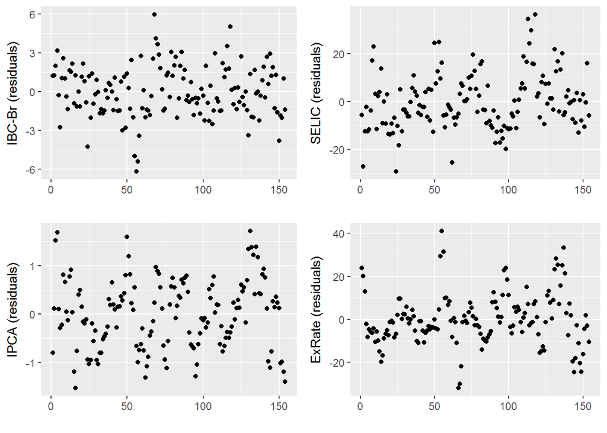

```r
library(ggplot2)
error <- Y-as.matrix(X)%*%as.matrix(A_post)

q1 <- qplot(seq_along(error[,1]), error[,1]) + xlab("")+ ylab("IBC-Br (residuals)")
q2 <- qplot(seq_along(error[,2]), error[,2]) + xlab("")+ ylab("IPCA (residuals)")
q3 <- qplot(seq_along(error[,3]), error[,3]) + xlab("")+ ylab("SELIC (residuals)")
q4 <- qplot(seq_along(error[,4]), error[,4]) + xlab("")+ ylab("ExRate (residuals)")

# Multiple plot function
#
# ggplot objects can be passed in ..., or to plotlist (as a list of ggplot objects)
# - cols:   Number of columns in layout
# - layout: A matrix specifying the layout. If present, 'cols' is ignored.
#
# If the layout is something like matrix(c(1,2,3,3), nrow=2, byrow=TRUE),
# then plot 1 will go in the upper left, 2 will go in the upper right, and
# 3 will go all the way across the bottom.
#
multiplot <- function(..., plotlist=NULL, file, cols=1, layout=NULL) {
  require(grid)

  # Make a list from the ... arguments and plotlist
  plots <- c(list(...), plotlist)

  numPlots = length(plots)

  # If layout is NULL, then use 'cols' to determine layout
  if (is.null(layout)) {
    # Make the panel
    # ncol: Number of columns of plots
    # nrow: Number of rows needed, calculated from # of cols
    layout <- matrix(seq(1, cols * ceiling(numPlots/cols)),
                    ncol = cols, nrow = ceiling(numPlots/cols))
  }

 if (numPlots==1) {
    print(plots[[1]])

  } else {
    # Set up the page
    grid.newpage()
    pushViewport(viewport(layout = grid.layout(nrow(layout), ncol(layout))))

    # Make each plot, in the correct location
    for (i in 1:numPlots) {
      # Get the i,j matrix positions of the regions that contain this subplot
      matchidx <- as.data.frame(which(layout == i, arr.ind = TRUE))

      print(plots[[i]], vp = viewport(layout.pos.row = matchidx$row,
                                      layout.pos.col = matchidx$col))
    }
  }
}

# Everything together
  multiplot(q1, q2, q3, q4, cols =2)
```

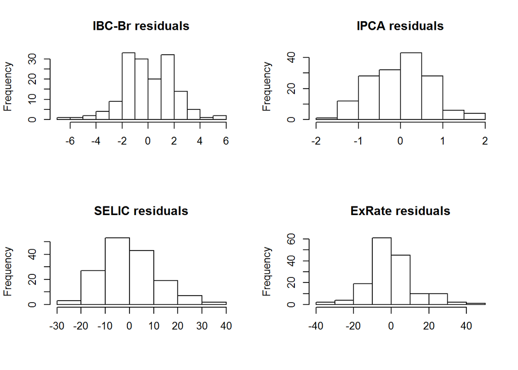

```r
par(mfrow=c(2,2))
hist(error[,1], main = "IBC-Br residuals", xlab="")
hist(error[,2], main = "IPCA residuals", xlab="")
hist(error[,3], main = "SELIC residuals", xlab="")
hist(error[,4], main = "ExRate residuals", xlab="")
```